# playground

TJ Sipin, Preeti Kulkarni

3/2/2022

# Introduction

## What is KOI?

NASA studies foreign bodies and planets in space by using highly developed technology. This project uses data from the Kepler Space Observatory, which is a NASA built satellite that was launched in 2009. NASA’s ultimate goal is finding other habitable planets besides Earth. NASA calls these possible habitable planets exoplanets. As of now, there are over 3000 confirmed exoplanets total, while the camera continues to do further exploration.

KOI stands for Kepler Objects of Interest. The data set we are exploring contains 10,000 exoplanet candidates that the Kepler Space Observatory has observations on (KOI). The observations depend on several variables and have many properties. We are interested in predicting the KOI disposition, which says whether a planet is confirmed, a false positive, or a candidate of being a KOI.

## Why Might This Model Be Useful?

This model is useful because it allows us to gain a better understanding and confidence on whether a planet is habitable or not, and to prioritize resources to planets predicted to be categorized as CONFIRMED or CANDIDATEs, which would save researchers time and money. It also allows us to figure out what factors are the most important when declaring a planet an exoplanet.

There is so much in space that we have not explored, and new discoveries can make a difference in history. The steps leading to those discoveries can be accomplished by using this model.

## Data Wrangling and Cleaning

The first thing we do is obtain the data set from https://exoplanetarchive.ipac.caltech.edu/cgi-bin/TblView/nph-tblView?app=ExoTbls&config=koi and select only a handful of predictors.

The most interesting predictors include:

- `koi_disposition` (our target variable): The category of this KOI from the Exoplanet Archive. Current values are CANDIDATE, FALSE POSITIVE, or CONFIRMED. All KOIs marked as CONFIRMED are also listed in the Exoplanet Archive Confirmed Planet table. Designations of CANDIDATE and FALSE POSITIVE are taken from the Disposition Using Kepler Data.
- `koi_period`: The interval between consecutive planetary transits.
- `koi_prad`: The radius of the planet. Planetary radius is the product of the planet star radius ratio and the stellar radius.
- `koi_teq`: Approximation for the temperature of the planet. The calculation of equilibrium temperature assumes a) thermodynamic equilibrium between the incident stellar flux and the radiated heat from the planet, b) a Bond albedo (the fraction of total power incident upon the planet scattered back into space) of 0.3, c) the planet and star are blackbodies, and d) the heat is evenly distributed between the day and night sides of the planet.
- `koi_insol`: Insolation flux is another way to give the equilibrium temperature. It depends on the stellar parameters (specifically the stellar radius and temperature), and on the semi-major axis of the planet. It’s given in units relative to those measured for the Earth from the Sun.
- `koi_dor`: The distance between the planet and the star at mid-transit divided by the stellar radius. For the case of zero orbital eccentricity, the distance at mid-transit is the semi-major axis of the planetary orbit.

The definitions are taken from the official dictionary of this data set: https://exoplanetarchive.ipac.caltech.edu/docs/API_kepcandidate_columns.html. All other definitions may be explored here.

```r
koi = read.csv("cumulative.csv")
koi <- dplyr::select(koi,-c(kepoi_name, koi_teq_err1, koi_teq_err2, rowid, kepid, kepler_name, koi_tce_delivname))

# data wrangle koi

koi = na.omit(koi)
koi = koi %>% dplyr::select(c(koi_disposition, koi_fpflag_nt, koi_fpflag_ss,
                              koi_fpflag_co, koi_fpflag_ec, koi_period, koi_time0bk, koi_impact,
                              koi_duration, koi_depth, koi_prad, koi_teq, koi_insol, koi_model_snr,
                              koi_steff, koi_slogg, koi_srad, ra, dec, koi_kepmag)) %>%
  mutate(koi_disposition = as.factor(koi_disposition)) %>%
  mutate(koi_fpflag_nt = factor(koi_fpflag_nt)) %>%
  mutate(koi_fpflag_ss = factor(koi_fpflag_ss)) %>%
  mutate(koi_fpflag_co = factor(koi_fpflag_co)) %>%
  mutate(koi_fpflag_ec = factor(koi_fpflag_ec))
```

## Exploratory Data Analysis

We first begin by looking at the correlation between predictors not including those that are of class factor and integer. We can see the rplot between the numeric factors. Overall, it seems as if predictors do not have a high correlation with each other, as there are many red dots.

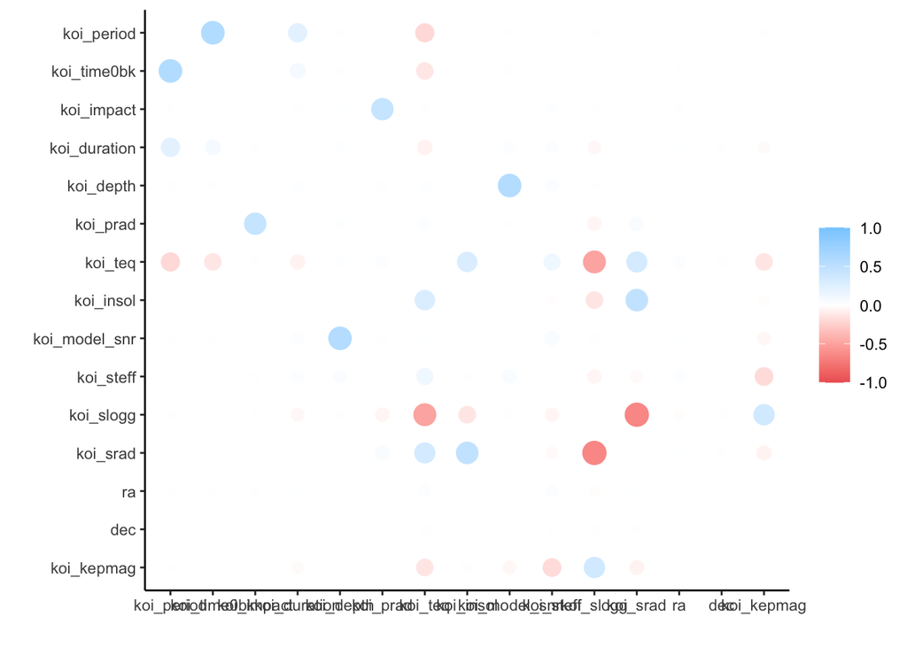

```r
# correlation
koi.corr <- koi %>%
  dplyr::select(-c(koi_disposition, koi_fpflag_co, koi_fpflag_ec, koi_fpflag_nt, koi_fpflag_ss)) %>%
  correlate()
rplot(koi.corr)
```

Next, we look at some descriptive statistics of the data set. We can use the `summary()` function to find the mean, median, min, max, and quartiles of the numeric predictors. We can use the `colnames()` function to familiarize ourselves with the column names.

# Data Exploration

```r
summary(koi)
```

```
##        koi_disposition koi_fpflag_nt koi_fpflag_ss koi_fpflag_co koi_fpflag_ec
##  CANDIDATE     :1772   0:6907        0:5744        0:6124        0:6760
##  CONFIRMED     :2268   1: 896        1:2059        1:1679        1:1043
##  FALSE POSITIVE:3763
##
##
##
##    koi_period         koi_time0bk       koi_impact       koi_duration
##  Min.   :   0.2598   Min.   : 120.6   Min.   : 0.0000   Min.   :  0.3028
##  1st Qu.:   2.4555   1st Qu.: 132.6   1st Qu.: 0.2130   1st Qu.:  2.4170
##  Median :   7.6984   Median : 136.0   Median : 0.5790   Median :  3.7360
##  Mean   :  37.3143   Mean   : 157.9   Mean   : 0.6097   Mean   :  5.3495
##  3rd Qu.:  24.0892   3rd Qu.: 159.8   3rd Qu.: 0.9075   3rd Qu.:  5.9730
##  Max.   :1071.2326   Max.   :1472.5   Max.   :25.2240   Max.   :138.5400
##    koi_depth           koi_prad           koi_teq        koi_insol
##  Min.   :     4.5   Min.   :    0.14   Min.   :   92   Min.   :       0
##  1st Qu.:   162.3   1st Qu.:    1.41   1st Qu.:  610   1st Qu.:      33
##  Median :   447.8   Median :    2.46   Median :  934   Median :     180
##  Mean   : 25728.0   Mean   :   26.97   Mean   : 1134   Mean   :    7680
##  3rd Qu.:  1862.3   3rd Qu.:   19.02   3rd Qu.: 1426   3rd Qu.:     976
##  Max.   :921670.0   Max.   :26042.90   Max.   :14667   Max.   :10947555
##  koi_model_snr       koi_steff       koi_slogg        koi_srad
##  Min.   :   2.40   Min.   : 2661   Min.   :0.047   Min.   :  0.109
##  1st Qu.:  14.40   1st Qu.: 5306   1st Qu.:4.228   1st Qu.:  0.826
##  Median :  27.40   Median : 5753   Median :4.442   Median :  0.993
##  Mean   : 298.20   Mean   : 5689   Mean   :4.320   Mean   :  1.678
##  3rd Qu.:  99.35   3rd Qu.: 6100   3rd Qu.:4.545   3rd Qu.:  1.319
##  Max.   :9054.70   Max.   :15896   Max.   :5.364   Max.   :180.013
##        ra             dec          koi_kepmag
##  Min.   :279.9   Min.   :36.58   Min.   : 6.966
##  1st Qu.:288.7   1st Qu.:40.81   1st Qu.:13.519
##  Median :292.3   Median :43.72   Median :14.582
##  Mean   :292.1   Mean   :43.84   Mean   :14.310
##  3rd Qu.:295.9   3rd Qu.:46.73   3rd Qu.:15.334
##  Max.   :301.7   Max.   :52.34   Max.   :19.065
```

# Graphs of univariate, multivariate relationships between outcome and predictor(s) or between predictors

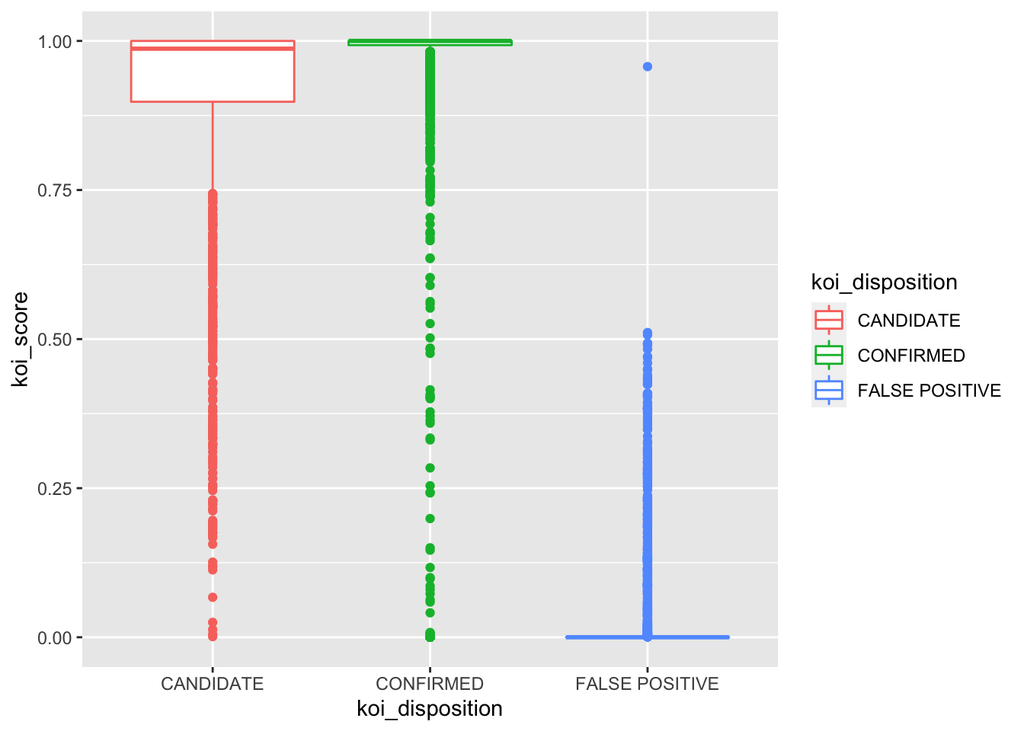

```r
#just curious about the koi_score v dispostion, shows up as first
koi_eda <- read.csv("cumulative.csv")

#score v disposition
koi_eda %>%
  ggplot() +
  aes(x= koi_disposition, y= koi_score, color = koi_disposition)+ geom_boxplot(show.legend = TRUE)
```

Next, we plot `koi_disposition` against `koi_prad`, where `koi_prad` is the radius of the planet. We are trying to see if there is a relationship with the radius and outcome of `koi_disposition`. It seems as if the confirmed planets have a smaller radius than the CANDIDATEs or FALSE POSITIVEs. We can also see one extrema in the FALSE POSITIVEs with a radius of over 20,000.

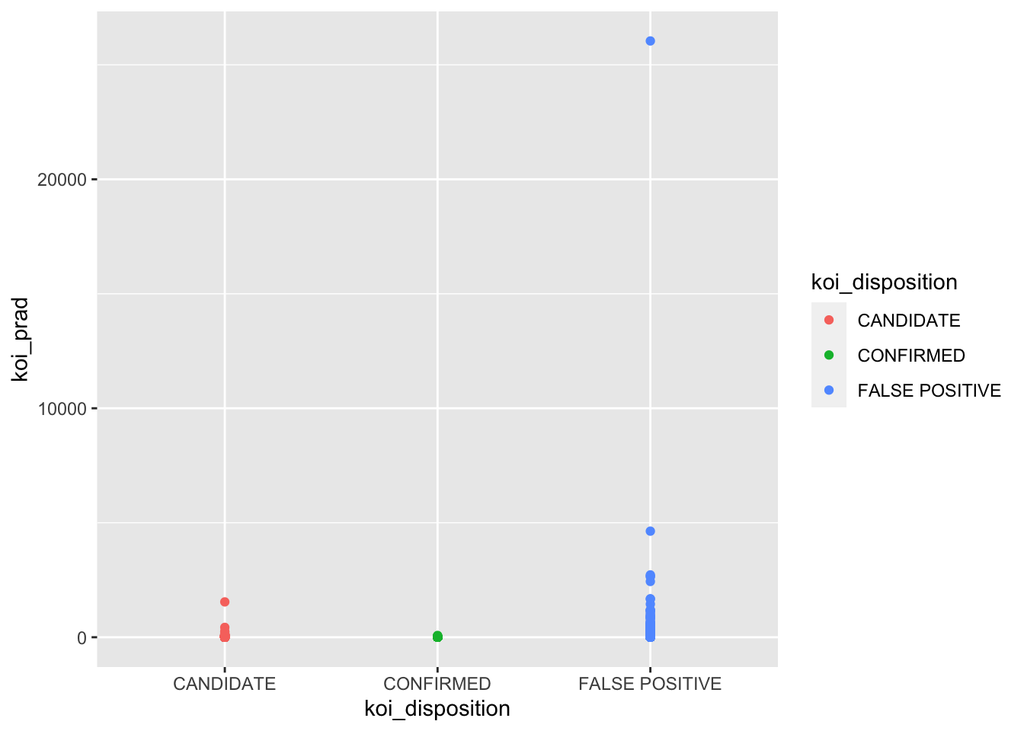

```r
#disposition v prad

ggplot(koi, aes(x= koi_disposition, y= koi_prad, color = koi_disposition)) + geom_point()
```

Now, focusing on `koi_disposition`, we can create a histogram to see the count of observations in each class. We can see that FALSE POSITIVEs have the highest count, being over 3,000. Confirmed follows next with around 2,300 and CANDIDATE has the smallest number of counts at around 1,800.

## Histograms

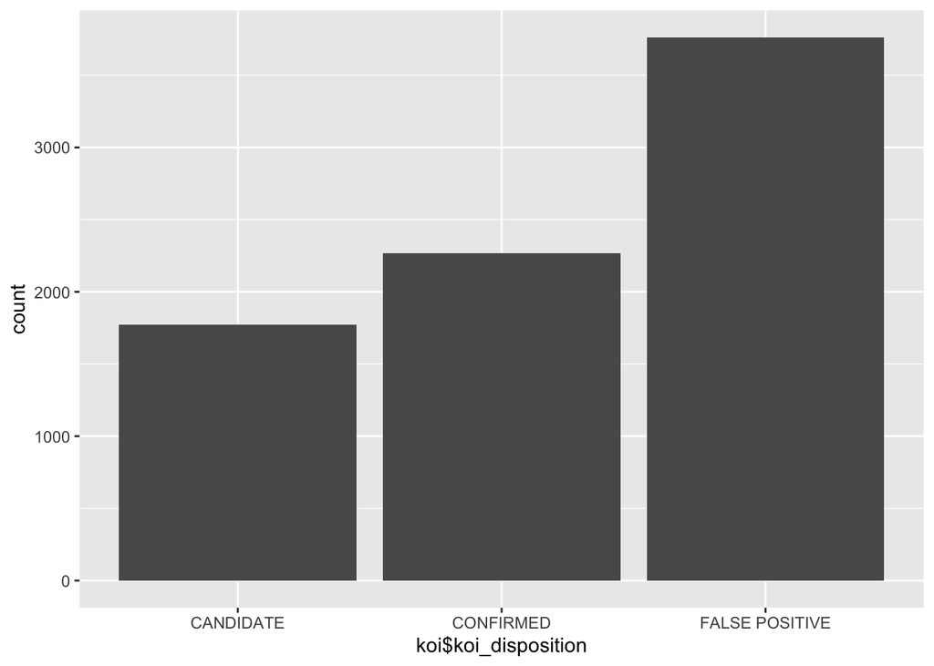

```r
ggplot(koi, aes(koi$koi_disposition)) +
  geom_bar(stat = "count")
```

## QQ Plot

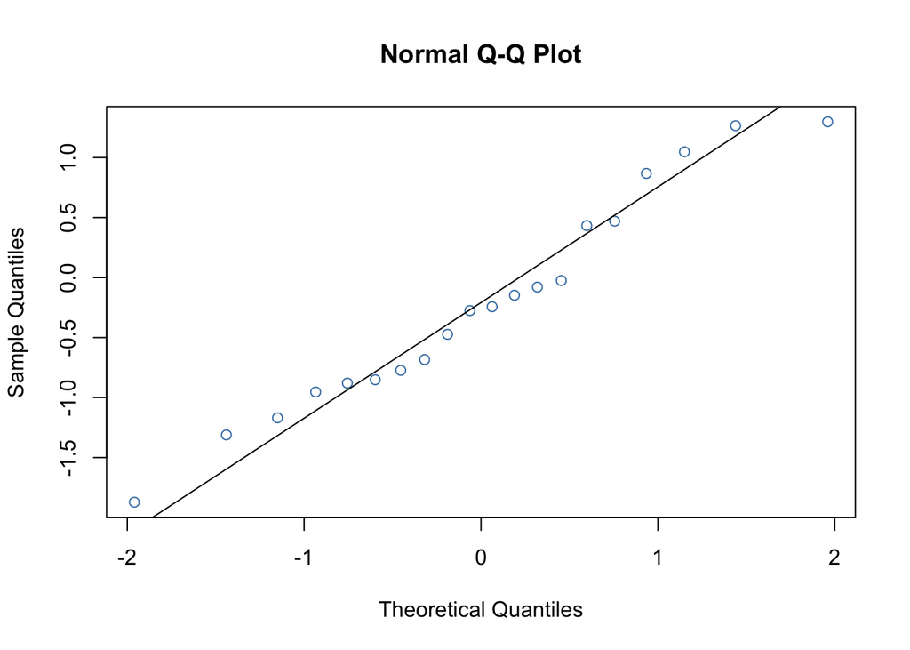

```r
data <- rnorm(koi)
qqnorm(data, col = "steelblue")
qqline(data)
```

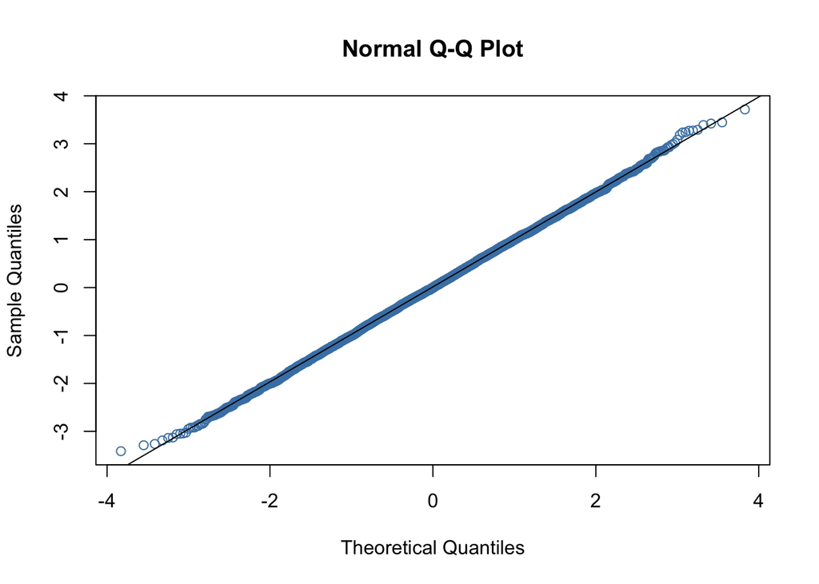

```r
set.seed(123)
data <- rnorm(koi$koi_disposition)
qqnorm(data, col = "steelblue")
qqline(data)
```

# Pre-Model Set-up

## Splitting KOI Data into Training and Testing Sets

So that the resamples have equivalent proportions as the original data set, we use the `tidymodels` version of training/test set splitting, with the `strata` argument set so that each resample is created within `koi_disposition`.

```r
# CV train and test split
koi_split <- initial_split(koi,
                           strata = koi_disposition)
koi_train <- training(koi_split)
koi_test <- testing(koi_split)
```

## Recipe

Using the framework from https://rviews.rstudio.com/2019/06/19/a-gentle-intro-to-tidymodels/, we create our recipe, centering and scaling numeric data to have a mean of zero and standard deviation of one. This recipe will be conveniently used for three out of our four models.

```r
# Recipe
recipe <- recipe(
  koi_disposition ~ koi_fpflag_nt + koi_fpflag_ss + koi_fpflag_co +
    koi_fpflag_ec + koi_period + koi_time0bk + koi_impact + koi_duration + koi_depth + koi_prad +
    koi_teq + koi_insol + koi_model_snr + koi_steff + koi_slogg + koi_srad +
    ra + dec + koi_kepmag, data = koi_train) %>%
  step_dummy(all_nominal(), -all_outcomes()) %>%
  step_normalize(all_predictors()) %>%
  step_zv(all_predictors()) %>%
  step_impute_median(all_predictors())
```

## Setting Up k-Fold Cross Validation

```r
koi_folds <- vfold_cv(koi_train)
save(koi_folds, recipe, file = "model_setup.rda")
```

# PCA

One of the dangers of performing PCA is that we lose interpretability in the predictors. Thus, we shouldn’t use PCA in our algorithms. However, we perform it anyway for data exploration. Here is a quick look of our `prcomp` object using `summary()`.

```r
pr.out = prcomp(koi[6:20], scale=T)
summary(pr.out)
```

```
## Importance of components:
##                           PC1    PC2    PC3    PC4     PC5     PC6     PC7
## Standard deviation     1.6717 1.3991 1.3329 1.2205 1.12136 1.01122 0.99154
## Proportion of Variance 0.1863 0.1305 0.1184 0.0993 0.08383 0.06817 0.06554
## Cumulative Proportion  0.1863 0.3168 0.4353 0.5345 0.61838 0.68655 0.75210
##                            PC8     PC9    PC10    PC11    PC12   PC13    PC14
## Standard deviation     0.89301 0.84217 0.74149 0.66395 0.61476 0.6000 0.54529
## Proportion of Variance 0.05316 0.04728 0.03665 0.02939 0.02519 0.0240 0.01982
## Cumulative Proportion  0.80526 0.85254 0.88920 0.91859 0.94378 0.9678 0.98760
##                          PC15
## Standard deviation     0.4312
## Proportion of Variance 0.0124
## Cumulative Proportion  1.0000
```

We set up our workflow, taking inspiration from https://cmdlinetips.com/2020/06/pca-with-tidymodels-in-r/.

```r
pca_trans <- recipe %>%
  step_center(all_numeric()) %>%
  step_scale(all_numeric()) %>%
  step_pca(all_numeric())

pca_estimates <- prep(pca_trans)

sdev <- pca_estimates$steps[[7]]$res$sdev

percent_variation <- sdev^2 / sum(sdev^2)

var_df <- data.frame(PC=paste0("PC", 1:length(sdev)),
                     var_explained=percent_variation,
                     stringsAsFactors = FALSE)
```

And now, we make a scree plot.

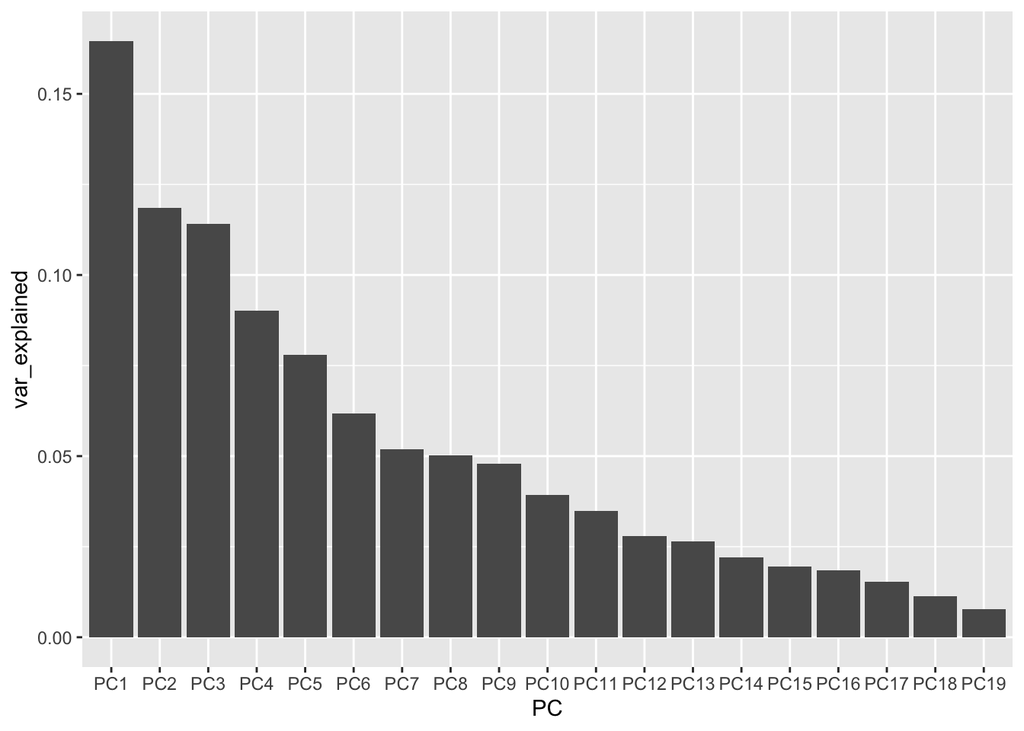

```r
var_df %>%
  mutate(PC = fct_inorder(PC)) %>%
  ggplot(aes(x=PC, y=var_explained)) +
  geom_col()
```

As we can see, there’s no PC that particularly stands out as none exceed 20% variance explained.

And here’s a plot of the cumulative sum of explained variance by each PC.

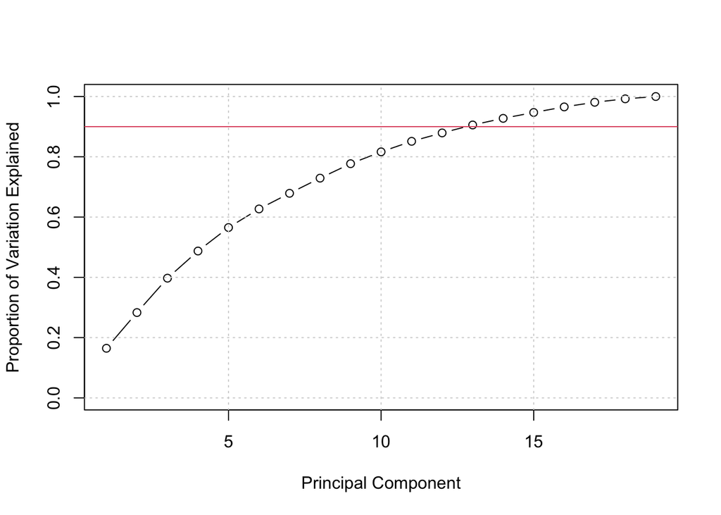

```r
plot(cumsum(percent_variation), xlab = "Principal Component",
     ylab = "Proportion of Variation Explained",
     ylim = c(0,1), type = 'b') %>%
  abline(h=.9, col = 2) %>%
  grid(col = "lightgray", lty = "dotted")
```

If we were to do PCA, we would use 13 PCs in our model building.

# Models

The four models we’ll use are K-Nearest Neighbors, Decision Tree, Boosted Trees, and Random Forest. The choice to use a decision tree is that it is not uncommon for it to be less accurate, so we wanted to see how it compares to the other models.

## K-Nearest Neighbors

First, we split the training and testing data sets into X (predictor) and Y (outcome) subsets.

```r
# lab04

XTrain = koi_train %>% dplyr::select(-koi_disposition)
YTrain = koi_train$koi_disposition
XTest = koi_test %>% dplyr::select(-koi_disposition)
YTest = koi_test$koi_disposition
```

Then, using the code from Lab 04, we create a function `do.chunk`, which carries out k-fold cross-validation and returns a data frame of all possible values of folds, with their training and validation errors.

```r
do.chunk <- function(chunkid, folddef, Xdat, Ydat, ...) {
  # Get training index
  train = (folddef!=chunkid)

  # Get training set by the above index
  Xtr = Xdat[train,]
  Ytr = Ydat[train]

  # Get validation set
  Xvl = Xdat[!train,]

  # Get responses in validation set
  Yvl = Ydat[!train]

  # Predict training labels``
  predYtr = knn(train=Xtr, test=Xtr, cl=Ytr, ...)

  # Predict validation labels
  predYvl = knn(train=Xtr, test=Xvl, cl=Ytr, ...)

  data.frame(fold = chunkid,
             train.error = mean(predYtr != Ytr), # Training error for each fold
             val.error = mean(predYvl != Yvl))
}
```

Like in the lab, we try a 3-fold cross-validation, trying from one to 50 neighbors. Then we save data frame `error.folds` so we don’t have to run it again.

```r
# Set 3-fold CV

nfold = 3

set.seed(123)
folds = cut(1:nrow(koi_train), breaks=nfold, labels=F) %>% sample()
folds


# Set error.folds as a vector to save validation errors in future
error.folds = NULL

# Give possible number of nearest neighbors to be considered
allK = 1:50

set.seed(234)

# Loop through different number of neighbors
for(k in allK) {
  # Loop through different chunk id
  for (j in seq(3)) {
    tmp = do.chunk(chunkid = j, folddef = folds, Xdat = XTrain, Ydat = YTrain, k = k)

    tmp$neighbors = k # Records last number of neighbor

    error.folds = rbind(error.folds, tmp) # combines results
  }
}

save(error.folds, file = "error.rda")
```

From `error.folds`, we choose the best number of neighbors based on validation error. If there was a tie in error rate, then we would choose the larger number of neighbors for a simpler model.

```r
load("error.rda")

head(error.folds, 10)
```

```
##    fold train.error val.error neighbors
## 1     1   0.0000000 0.4459252         1
## 2     2   0.0000000 0.4276923         1
## 3     3   0.0000000 0.4331112         1
## 4     1   0.2063573 0.4643772         2
## 5     2   0.2401333 0.4384615         2
## 6     3   0.2222507 0.4454126         2
## 7     1   0.2317355 0.4243977         3
## 8     2   0.2442337 0.4046154         3
## 9     3   0.2345552 0.4105587         3
## 10    1   0.2655729 0.4161968         4
```

```r
# Transform the format of error.folds for further convenience
errors = melt(error.folds, id.vars = c('fold', 'neighbors'), value.name = 'error')

# Choose the number of neighbors which minimizes validation error
val.error.means = errors %>%
  # Select all rows of validation errors
  filter(variable=='val.error') %>%
  # Group the selected data frame by neighbors
  group_by(neighbors, variable) %>%
  # Calculate CV error rate for each k
  summarise_each(funs(mean), error) %>%
  # Remove existing group
  ungroup() %>%
  filter(error==min(error))

# Best num of neighbors (if tie, pick larger number of neighbors for simpler model)

bestneighbor = max(val.error.means$neighbors)

set.seed(345)
pred.YTest = knn(train = XTrain, test = XTest, cl = YTrain, k = bestneighbor)

# Confusion matrix
conf.matrix = table(predicted = pred.YTest, true = YTest)

# Test error rate

print(paste("Test error rate: ", 1 - sum(diag(conf.matrix)/sum(conf.matrix))))
```

```
## [1] "Test error rate:  0.349051768323936"
```

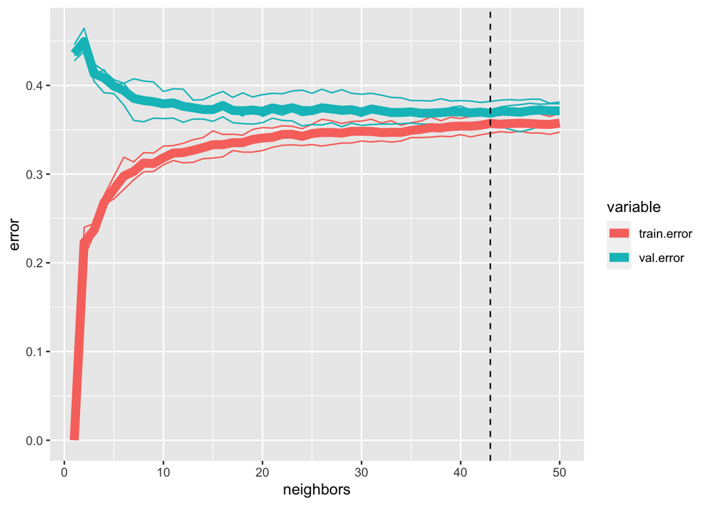

```r
# Plot errors
ggplot(errors, aes(x = neighbors, y = error, color = variable)) +
  geom_line(aes(group = interaction(variable,fold))) +
  stat_summary(aes(group = variable), fun = "mean", geom = "line", size = 3) +
  geom_vline(aes(xintercept = bestneighbor), linetype = "dashed")
```

Out of curiosity, let’s try KNN on only a few predictors (`koi_period`, `koi_teq`, `koi_insol`, `koi_srad`, `koi_impact`, and `koi_steff`). These predictors were chosen because we think that the measurements can be obtained easier than the others.

```r
XTrain.few = koi_train %>% dplyr::select(c(-koi_disposition, koi_period, koi_teq, koi_insol, koi_srad, koi_impact, koi_steff))
YTrain.few = koi_train$koi_disposition
XTest.few = koi_test %>% dplyr::select(c(-koi_disposition, koi_period, koi_teq, koi_insol, koi_srad, koi_impact, koi_steff))
YTest.few = koi_test$koi_disposition



# Set 3-fold CV

nfold = 3

set.seed(123)
folds = cut(1:nrow(koi_train), breaks=nfold, labels=F) %>% sample()
folds


# Set error.folds as a vector to save validation errors in future
error.folds.few = NULL

# Give possible number of nearest neighbors to be considered
allK = 1:50

set.seed(234)

# Loop through different number of neighbors
for(k in allK) {
  # Loop through different chunk id
  for (j in seq(3)) {
    tmp = do.chunk(chunkid = j, folddef = folds, Xdat = XTrain.few, Ydat = YTrain.few, k = k)

    tmp$neighbors = k # Records last number of neighbor

    error.folds.few = rbind(error.folds.few, tmp) # combines results
  }
}

save(XTrain.few, YTrain.few, XTest.few, YTest.few, error.folds.few, file = "errorfew.rda")
```

```r
load("errorfew.rda")

# Transform the format of error.folds for further convenience
errors = melt(error.folds.few, id.vars = c('fold', 'neighbors'), value.name = 'error')

# Choose the number of neighbors which minimizes validation error
val.error.means.few = errors %>%
  # Select all rows of validation errors
  filter(variable=='val.error') %>%
  # Group the selected data frame by neighbors
  group_by(neighbors, variable) %>%
  # Calculate CV error rate for each k
  summarise_each(funs(mean), error) %>%
  # Remove existing group
  ungroup() %>%
  filter(error==min(error))

# Best num of neighbors (if tie, pick larger number of neighbors for simpler model)

bestneighbor.few = max(val.error.means.few$neighbors)

set.seed(345)
pred.YTest.few = knn(train = XTrain.few, test = XTest.few, cl = YTrain.few, k = bestneighbor.few)

# Confusion matrix
conf.matrix = table(predicted = pred.YTest.few, true = YTest.few)

# Test error rate

print(paste("Test error rate: ", 1 - sum(diag(conf.matrix)/sum(conf.matrix))))
```

```
## [1] "Test error rate:  0.349051768323936"
```

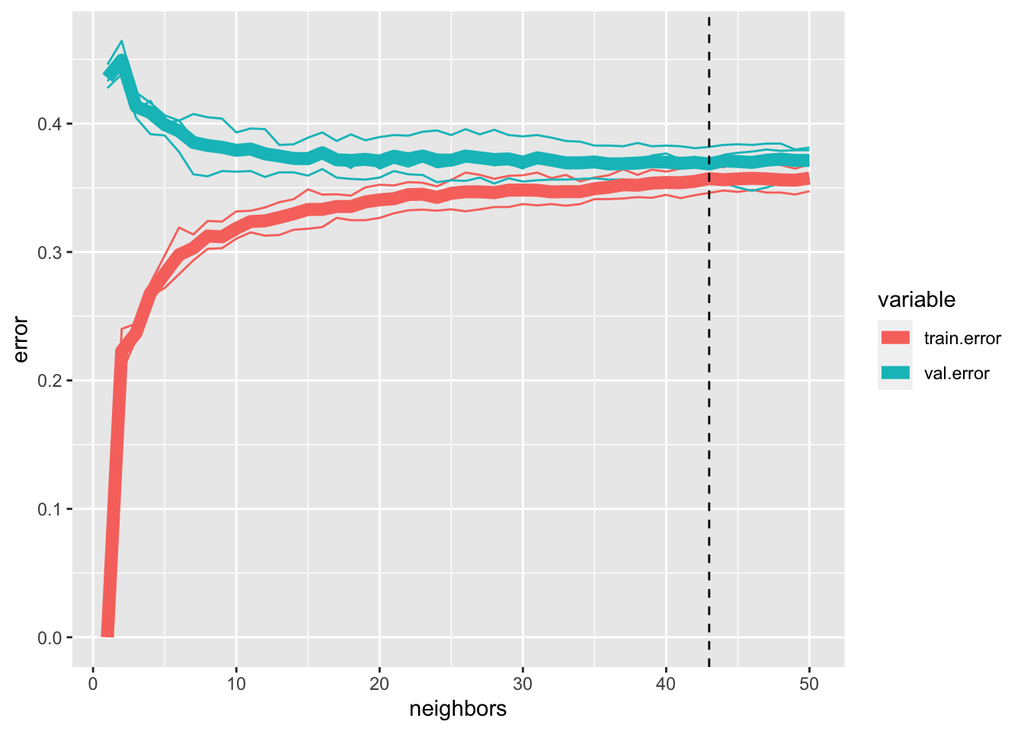

```r
# Plot errors
ggplot(errors, aes(x = neighbors, y = error, color = variable)) +
  geom_line(aes(group = interaction(variable,fold))) +
  stat_summary(aes(group = variable), fun = "mean", geom = "line", size = 3) +
  geom_vline(aes(xintercept = bestneighbor.few), linetype = "dashed")
```

## Decision Tree

```r
#creating the model

tree_model <- decision_tree() %>%
  set_engine("rpart") %>%
  set_mode("classification")

set.seed(1)
koi$koi_disposition <- as.factor(koi$koi_disposition)
cell_folds <- vfold_cv(koi_train, v = 5)
```

Our first steps with the tree is to create the framework and workflow of the classification model. The `rpart` engine is used, and `koi_disposition` is transformed from character to factor.

```r
tree_wf <- workflow() %>%
  add_recipe(recipe)%>%
  add_model(tree_model)

# Tree Grid
tree_grid <- grid_regular(
  cost_complexity(),
  tree_depth(),
  levels = 5
)

tree_res <- tree_wf %>%
  tune_grid(
    resamples = cell_folds,
    grid = tree_grid
  )

param_grid <- grid_regular(cost_complexity(range = c(-3, -1)), levels = 10)

tune_res <- tune_grid(
  tree_wf,
  resamples = cell_folds,
  grid = param_grid,
  metrics = metric_set(accuracy)
)
```

Our next step is to set up different parts of the model, beginning with the workflow and tree grid. The tree grid shows us a great visual table of the `cost_complexity` and the `tree_depth`. Then, for cross validation, we create 5 folds, and a tree grid with cost complexity and depth, that would be tuned through `param_grid`. `param_grid` is a grid created with different values that the model could go through, with 10 levels. Then, for the classification problem, we are looking at accuracy, so our metric is always set to accuracy.

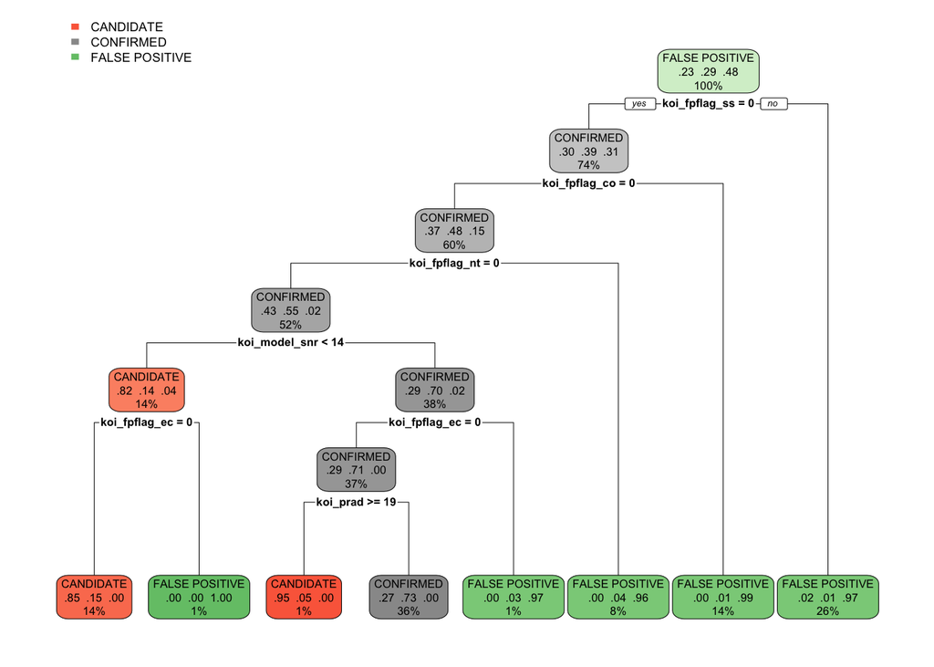

```r
tree_spec <- decision_tree() %>%
  set_engine("rpart")

#classification tree

class_tree_spec <- tree_spec %>%
  set_mode("classification")

#making column into factor

koi_train$koi_disposition <-as.factor(koi_train$koi_disposition)

class_tree_fit <- class_tree_spec %>%
  fit(koi_disposition ~ ., data = koi_train)

class_tree_fit %>%
  extract_fit_engine() %>%
  rpart.plot()
```

Now, we use the training data to fit `koi_disposition` against the other predictors, and can see the tree we made.

```r
#the confusion matrix

confmat = augment(class_tree_fit, new_data = koi_train) %>%
  conf_mat(truth = koi_disposition, estimate = .pred_class)
confmat
```

```
##                 Truth
## Prediction       CANDIDATE CONFIRMED FALSE POSITIVE
##   CANDIDATE            733       122              0
##   CONFIRMED            571      1531              0
##   FALSE POSITIVE        25        48           2822
```

```r
# Accuracy
accurate = augment(class_tree_fit, new_data = koi_train) %>%
  accuracy(truth = koi_disposition, estimate = .pred_class)
accurate
```

```
## # A tibble: 1 × 3
##   .metric  .estimator .estimate
##   <chr>    <chr>          <dbl>
## 1 accuracy multiclass     0.869
```

Next, we try our model on the training data and obtain its confusion matrix, which gives us an accuracy of ~0.87, which is much better than expected and much better than the KNN model. Even without tuning, this is a great model. Let’s try tuning.

```r
#fitting the model on training data

class_tree_wf <- workflow() %>%
  add_model(class_tree_spec %>% set_args(cost_complexity = tune())) %>%
  add_recipe(recipe)

param_grid <- grid_regular(cost_complexity(range = c(-3, -1)), levels = 10)
```

Now that we fit our tree model for cross-validation, we use a popular workflow used by many people in the machine learning community.

```r
tune_res <- tune_grid(
  class_tree_wf,
  resamples = cell_folds,
  grid = param_grid,
  metrics = metric_set(accuracy))

save(tune_res, file = "tree_tune.rda")
```

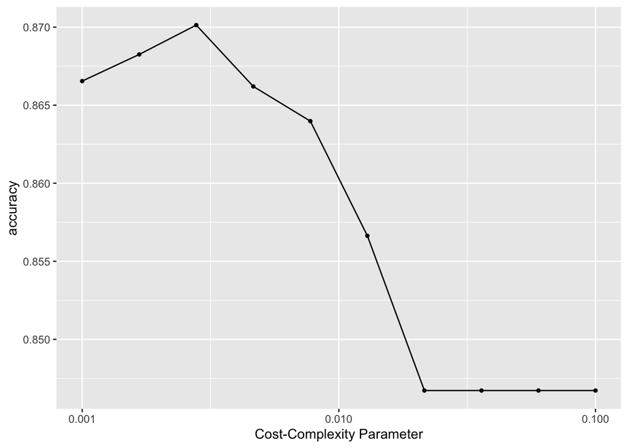

```r
load("tree_tune.rda")

autoplot(tune_res)
```

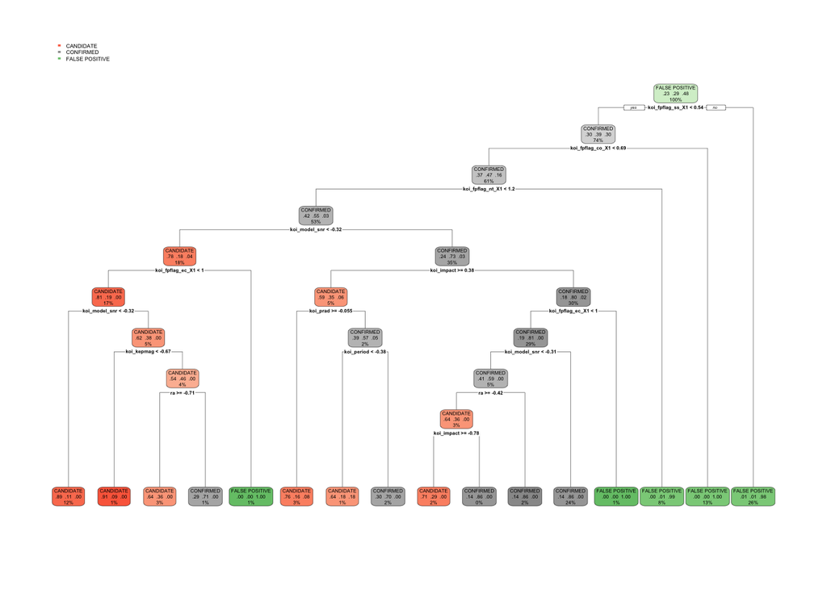

```r
best_complexity <- select_best(tune_res)

class_tree_final <- finalize_workflow(class_tree_wf, best_complexity)

koi_test$koi_disposition <- as.factor(koi_test$koi_disposition)

class_tree_final_fit <- fit(class_tree_final, data = koi_test)


class_tree_final_fit %>%
  extract_fit_engine() %>%
  rpart.plot()
```

```r
final_tree_fit = class_tree_final %>% last_fit(koi_split)

final_tree_fit %>%
  collect_metrics()
```

```
## # A tibble: 2 × 4
##   .metric  .estimator .estimate .config
##   <chr>    <chr>          <dbl> <chr>
## 1 accuracy multiclass     0.890 Preprocessor1_Model1
## 2 roc_auc  hand_till      0.937 Preprocessor1_Model1
```

## Boosted Tree

As we did previously, we first begin by creating the framework of the model, using classification and xgboost as the engine. Our tuning parameters are min_n, mtry, and learn_rate. Again, we add a workflow model, and parameters to tune.

As we did previously, we first begin by creating the framework of the model, using classification and `xgboost` as the engine. Our tuning parameters are `min_n`, `mtry`, and `learn_rate`.

```r
# Creating model

boost_model <- boost_tree(min_n= tune(),
                          mtry =tune(),
                          learn_rate= tune(),
                          mode = "classification") %>%
  set_engine("xgboost")

boost_wflow <-
  workflow() %>%
  add_recipe(recipe) %>%
  add_model(boost_model)

boost_params <- parameters(boost_model) %>%
  update(mtry = mtry(range = c(2, 12)))
```

```r
# Define grid

boost_grid <- grid_regular(boost_params,
                           levels=3
)

# Tuning model

boost_tune <- boost_wflow %>%
  tune_grid(resamples = koi_folds,
            grid = boost_grid)

# Boost results for metrics

boost_res <-
  boost_wflow %>%
    tune_grid(resamples = koi_folds,
          grid = boost_grid,
          metrics = metric_set(
            recall, precision, f_meas,
            accuracy, kap,
            roc_auc, sens, spec
          ))

save(boost_tune, boost_res, file = "boost_tune.rda")
```

```r
load("boost_tune.rda")

best_complexity <- select_best(boost_res, metric = "accuracy")

class_boost_final <- finalize_workflow(boost_wflow, best_complexity)

koi_test$koi_disposition <- as.factor(koi_test$koi_disposition)

class_boost_final_fit <- fit(class_boost_final, data = koi_test)
```

```
## [19:28:17] WARNING: amalgamation/../src/learner.cc:1115: Starting in XGBoost 1.3.0, the default evaluation metric used with the objective 'multi:softprob' was changed from 'merror' to 'mlogloss'. Explicitly set eval_metric if you'd like to restore the old behavior.
```

```r
final_boost_fit = class_boost_final %>% last_fit(koi_split)

final_boost_fit %>%
  collect_metrics()
```

```
## # A tibble: 2 × 4
##   .metric  .estimator .estimate .config
##   <chr>    <chr>          <dbl> <chr>
## 1 accuracy multiclass     0.890 Preprocessor1_Model1
## 2 roc_auc  hand_till      0.954 Preprocessor1_Model1
```

## Random Forest

As usual, we set up our model workflow. We set `mtry` to a range of two to 12 in our cross-validation.

```r
rf_model <-
  rand_forest(min_n = tune(),
              mtry = tune(),
              mode = "classification") %>%
  set_engine("ranger")


rf_workflow <- workflow() %>%
  add_model(rf_model)  %>%
  add_recipe(recipe)

rf_params <- parameters(rf_model) %>%
  update(mtry = mtry(range = c(2, 12)))


rf_grid <- grid_regular(rf_params,
                        levels = 3)
```

```r
rf_tune <- rf_workflow %>%
  tune_grid(resamples = koi_folds,
            grid = rf_grid)

save(rf_tune, rf_workflow, file = "rf_tune.rda")
```

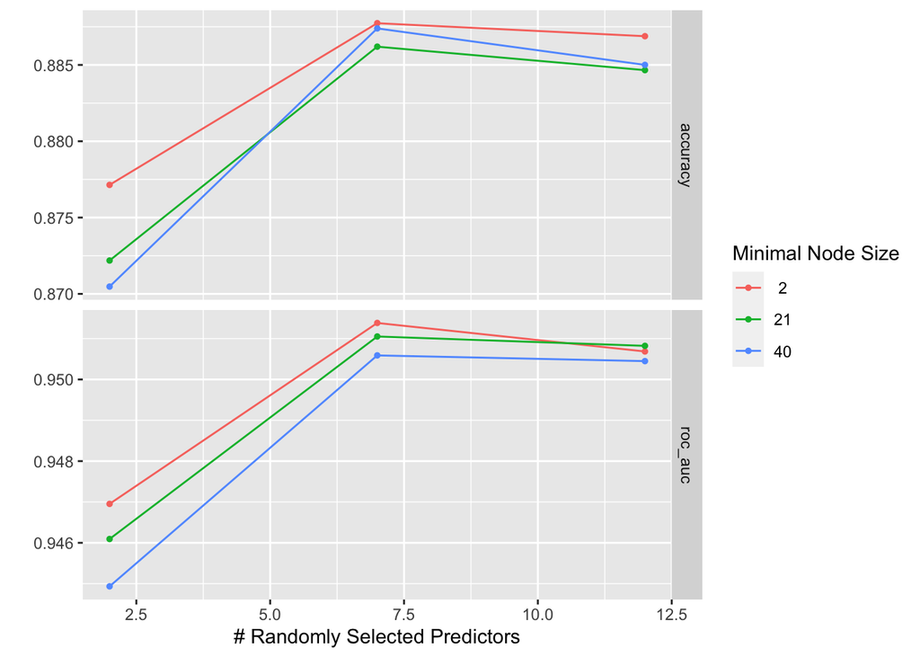

```r
load("rf_tune.rda")

autoplot(rf_tune)
```

```r
show_best(rf_tune, metric = "accuracy") %>% dplyr::select(-.estimator, -.config)
```

```
## # A tibble: 5 × 6
##    mtry min_n .metric   mean     n std_err
##   <int> <int> <chr>    <dbl> <int>   <dbl>
## 1     7     2 accuracy 0.888    10 0.00444
## 2     7    40 accuracy 0.887    10 0.00457
## 3    12     2 accuracy 0.887    10 0.00461
## 4     7    21 accuracy 0.886    10 0.00527
## 5    12    40 accuracy 0.885    10 0.00501
```

We see an accuracy of ~0.888 for a random forest with parameters `mtry = 7` and `min_n = 2`.

```r
best_complexity <- select_best(rf_tune, metric = "accuracy")

class_rf_final <- finalize_workflow(rf_workflow, best_complexity)

class_rf_final_fit <- fit(class_rf_final, data = koi_test)

final_rf_fit = class_rf_final %>% last_fit(koi_split)

final_rf_fit %>%
  collect_metrics()
```

```
## # A tibble: 2 × 4
##   .metric  .estimator .estimate .config
##   <chr>    <chr>          <dbl> <chr>
## 1 accuracy multiclass     0.890 Preprocessor1_Model1
## 2 roc_auc  hand_till      0.955 Preprocessor1_Model1
```

Our random forest performs better by only 0.001 compared to the boosted tree model. Even though the improvement is negligible, we’ll still use the random forest as our best model and explore it.

# Best Model

Upon comparison among all four models, the random forest performed the best on the test data, but by only a margin of 0.001 compared to the boosted tree model.

We use https://rviews.rstudio.com/2019/06/19/a-gentle-intro-to-tidymodels/ as a guide to explore other metrics.

First, we make a final model by taking the best parameters obtained (`min_n = 2` and `mtry = 7`) in the previous section and run the fit.

```r
koi_train$koi_disposition <- as.factor(koi_train$koi_disposition)
koi_test$koi_disposition <- as.factor(koi_test$koi_disposition)

final_model <-
  rand_forest(min_n = 2,
              mtry = 7,
              mode = "classification") %>%
  set_engine("ranger") %>%
  fit(koi_disposition ~ ., data = koi_train)

final_model %>%
  predict(koi_test) %>%
  bind_cols(koi_test) %>%
  metrics(truth = koi_disposition, estimate = .pred_class)
```

```
## # A tibble: 2 × 3
##   .metric  .estimator .estimate
##   <chr>    <chr>          <dbl>
## 1 accuracy multiclass     0.894
## 2 kap      multiclass     0.832
```

Now we can explore the performance of our model by each predicted value in our sample space: CANDIDATE, CONFIRMED, and FALSE POSITIVE.

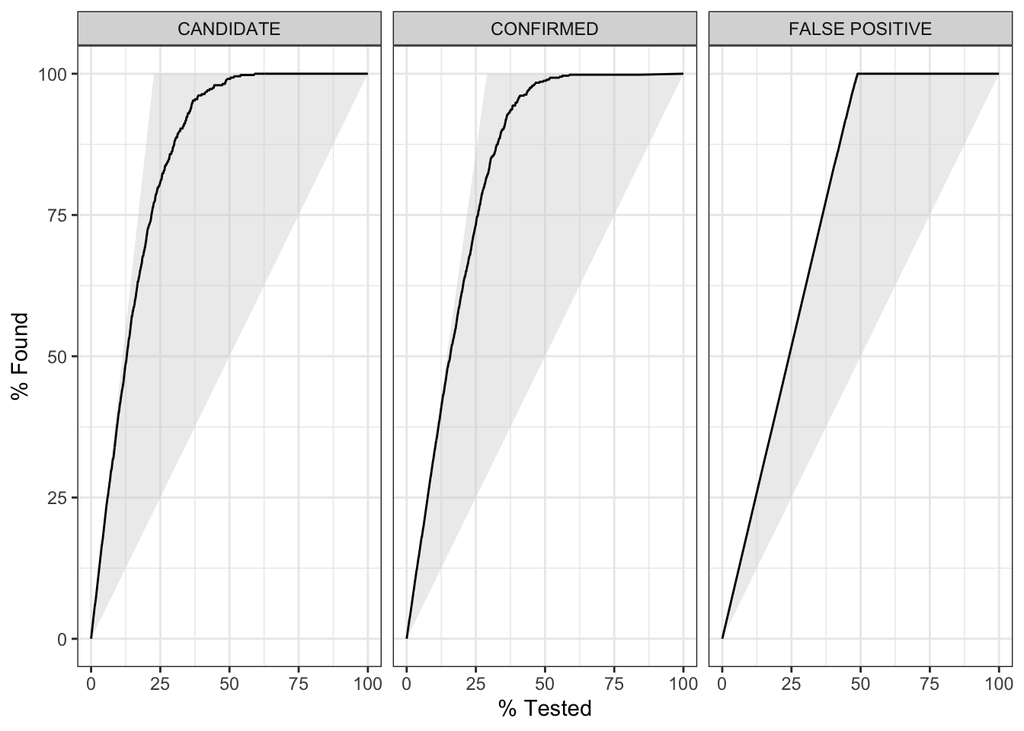

```r
# Per classifier metrics

koi_probs <- final_model %>%
  predict(koi_test, type = "prob") %>%
  bind_cols(koi_test)

# gain curve plot
koi_probs %>%
  gain_curve(koi_disposition, .pred_CANDIDATE:`.pred_FALSE POSITIVE`) %>%
  autoplot()
```

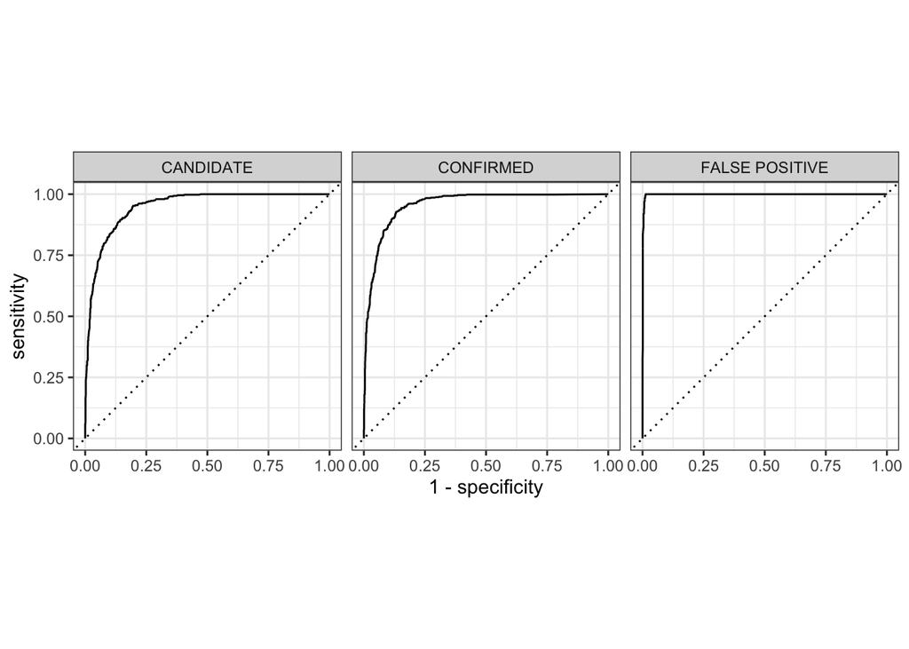

```r
# if we target 25% of observations with highest probability of being CANDIDATE,
# we will get ~80% of all possible CANDIDATE observations

# roc curve plot
koi_probs %>%
  roc_curve(koi_disposition, .pred_CANDIDATE:`.pred_FALSE POSITIVE`) %>%
  autoplot()
```

```r
# koi_disposition observations with FALSE POSITIVE have close to optimal model,
# CONFIRMED is good, and CANDIDATE is worst (still pretty good)
```

We ran both a gain curve plot and an ROC AUC plot. The ROC AUC plot is highly promising, with the FALSE POSITIVE plot very close to the optimal plot. The plots for the other outcomes are also similarly good. Additionally, the gain curve plot tells us that for CANDIDATE and CONFIRMED, among the 25% of observations with highest probability of being CANDIDATE and CONFIRMED respectively, we will get ~75% of allCANDIDATE and CONFIRMED observations.

We now run different metrics and see the estimates for each.

```r
predict(final_model, koi_test, type = "prob") %>%
  bind_cols(predict(final_model, koi_test)) %>%
  bind_cols(dplyr::select(koi_test, koi_disposition)) %>%
  metrics(koi_disposition, .pred_CANDIDATE:`.pred_FALSE POSITIVE`, estimate = .pred_class)
```

```
## # A tibble: 4 × 3
##   .metric     .estimator .estimate
##   <chr>       <chr>          <dbl>
## 1 accuracy    multiclass     0.894
## 2 kap         multiclass     0.832
## 3 mn_log_loss multiclass     0.278
## 4 roc_auc     hand_till      0.956
```

Overall, we have a very high accuracy similar to our boosted tree and pruned models on our testing data.

Like with what we did with KNN, let’s try running the tree on the same few predictors that we believe are easier to obtain, like `koi_period`, `koi_teq`, `koi_insol`, `koi_srad`, `koi_impact`, and `koi_steff`.

We create a mini recipe first.

```r
recipe.few <- recipe(
  koi_disposition ~ koi_period + koi_teq + koi_insol + koi_srad + koi_impact + koi_steff, data = koi_train) %>%
  step_dummy(all_nominal(), -all_outcomes()) %>%
  step_normalize(all_predictors()) %>%
  step_zv(all_predictors()) %>%
  step_impute_median(all_predictors())
```

Then we perform the same process as above to find the best parameters.

```r
rf_model <-
  rand_forest(min_n = tune(),
              mtry = tune(),
              mode = "classification") %>%
  set_engine("ranger")


rf_workflow.few <- workflow() %>%
  add_model(rf_model)  %>%
  add_recipe(recipe.few)

rf_params.few <- parameters(rf_model) %>%
  update(mtry = mtry(range = c(2, 6)))


rf_grid.few <- grid_regular(rf_params.few,
                        levels = 3)
```

```r
rf_tune.few <- rf_workflow.few %>%
  tune_grid(resamples = koi_folds,
            grid = rf_grid.few)

save(rf_tune.few, rf_workflow.few, file = "rf_tune_few.rda")
```

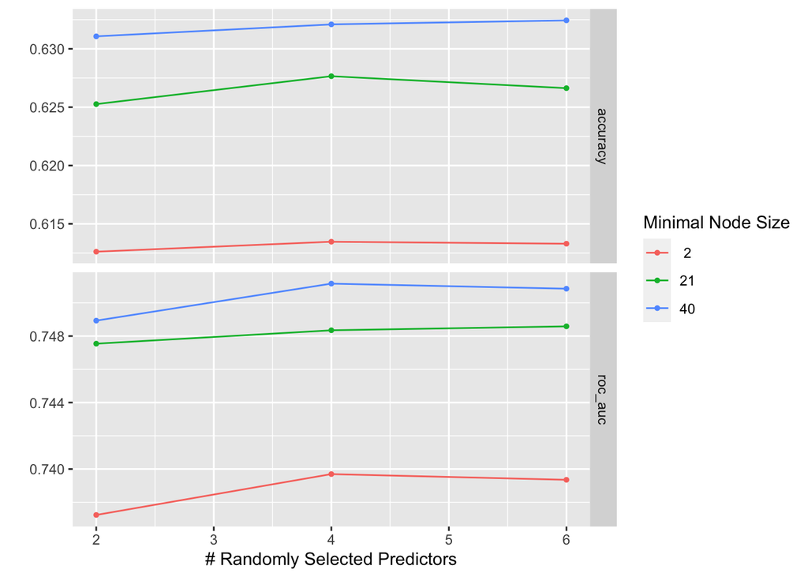

```r
load("rf_tune_few.rda")

autoplot(rf_tune.few)
```

```r
show_best(rf_tune.few, metric = "accuracy") %>% dplyr::select(-.estimator, -.config)
```

```
## # A tibble: 5 × 6
##    mtry min_n .metric   mean     n std_err
##   <int> <int> <chr>    <dbl> <int>   <dbl>
## 1     6    40 accuracy 0.632    10 0.00853
## 2     4    40 accuracy 0.632    10 0.00924
## 3     2    40 accuracy 0.631    10 0.00836
## 4     4    21 accuracy 0.628    10 0.00847
## 5     6    21 accuracy 0.627    10 0.00839
```

```r
best_complexity.few <- select_best(rf_tune.few, metric = "accuracy")

class_rf_final.few <- finalize_workflow(rf_workflow.few, best_complexity.few)

class_rf_final_fit.few <- fit(class_rf_final.few, data = koi_test)



final_rf_fit.few = class_rf_final.few %>% last_fit(koi_split)

final_rf_fit.few %>%
  collect_metrics()
```

```
## # A tibble: 2 × 4
##   .metric  .estimator .estimate .config
##   <chr>    <chr>          <dbl> <chr>
## 1 accuracy multiclass     0.635 Preprocessor1_Model1
## 2 roc_auc  hand_till      0.756 Preprocessor1_Model1
```

As expected, the model performs much worse than with more predictors. It’s my guess that this is because each predictor is relatively similarly equivalent in significance, as we see in the PCA section. However, maybe through cross-validation, we can obtain the right parameters for the random forest to use with these predictors.

# Conclusion

We did not expect our KNN model to work as well as the rest because of the sensitivity to outliers, the assumption that similar points share similar labels, and the fact that we have a large data set. Furthermore, we know KNN is not good for large data sets since the training data is processed for every predictor, making it an inefficient model. However, for observations with less data, KNN did work better than the random forest model.

For the full set of predictors, since the Decision Tree, Boosted Trees, and Random Forest models pushed towards an accuracy of 90% on testing data, we can be quite confident that implementation of our model can result in a more efficient workflow for KOI researchers as they can now prioritize objects predicted to be CANDIDATEs or CONFIRMED. It must be reiterated that this only works for observations with the properties we used in our model already. Further development of models that use properties that are easier to obtain is a necessary next step to further workflow efficiency for those studying KOIs.